# Answer Set 1 — Geoms and Aesthetics

Rockefeller University, Bioinformatics Resource Centre

https://rockefelleruniversity.github.io/Plotting_In_R/

These answers are for the exercises that cover the Geoms and Aesthetics of ggplot2 for [Plotting in R](https://rockefelleruniversity.github.io/Plotting_In_R/).

## Exercise 1

These first few exercises will run through some of the simple principles of creating a ggplot2 object, assigning aesthetics mappings and geoms.

1. Read in the cleaned patients dataset as we saw in ggplot2 course earlier (“patients_clean_ggplot2.txt”)

```r
getwd()
```

```
## [1] "/Users/mattpaul/Documents/Box Sync/RU/Teaching/RU_side/Plotting_In_R/r_course"
```

```r
patients_clean <- read.delim("./data/patients_clean_ggplot2.txt",sep="\t")
```

### Scatterplots

2. Using the patient dataset generate a scatter plot of BMI versus Weight.

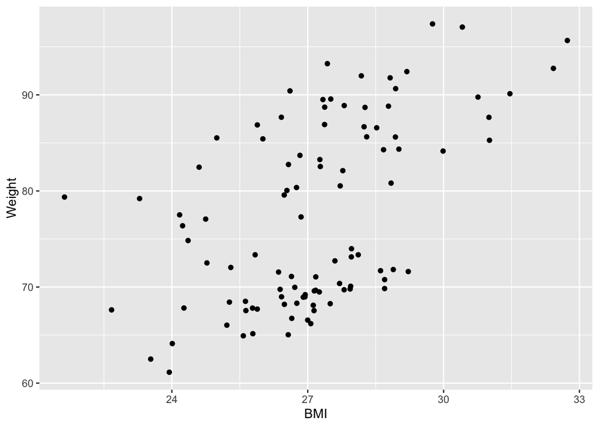

```r
library(ggplot2)

plot <- ggplot(data=patients_clean,
               mapping=aes(x=BMI,y=Weight))+geom_point()
plot
```

3. Extending the plot from exercise 2, add a colour scale to the scatterplot based on the Height variable.

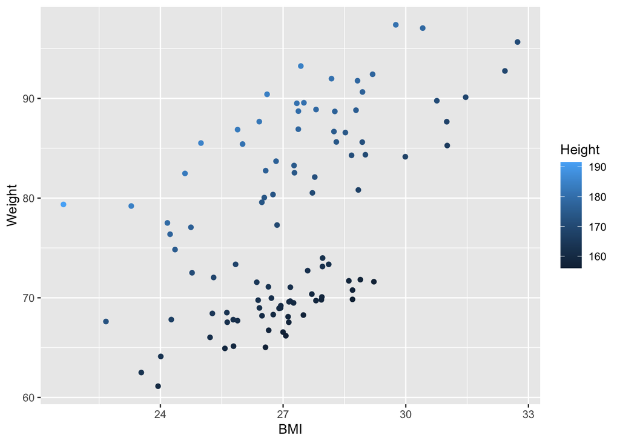

```r
plot <- ggplot(data=patients_clean,
               mapping=aes(x=BMI,y=Weight,colour=Height))+geom_point()
plot
```

4. Following from exercise 3, split the BMI vs Weight plot into a grid of plots separated by Smoking status and Sex .

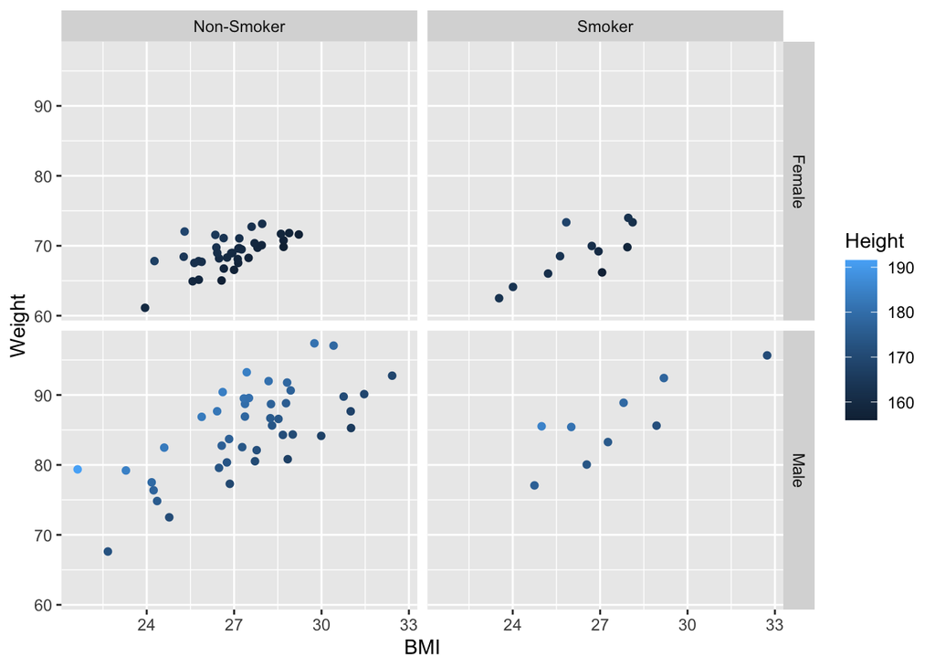

```r
plot <- ggplot(data=patients_clean,
               mapping=aes(x=BMI,y=Weight,colour=Height))+geom_point()
plot+facet_grid(Sex~Smokes)
```

5. Using an additional geom, add an extra layer of a fit line to the solution from exercise 3.

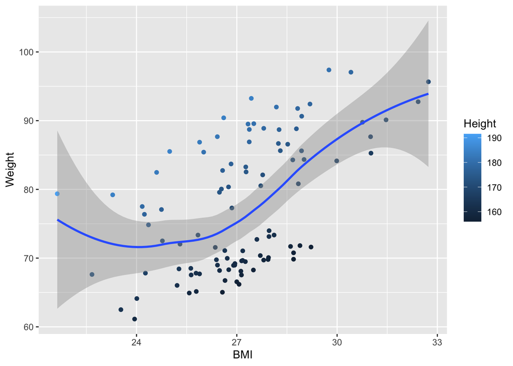

```r
plot <- ggplot(data=patients_clean,
               mapping=aes(x=BMI,y=Weight,colour=Height))+geom_point()+
  geom_smooth()
plot
```

6. Does the fit in question 5 look good? Look at the description for ?geom_smooth() and adjust the method for a better fit.

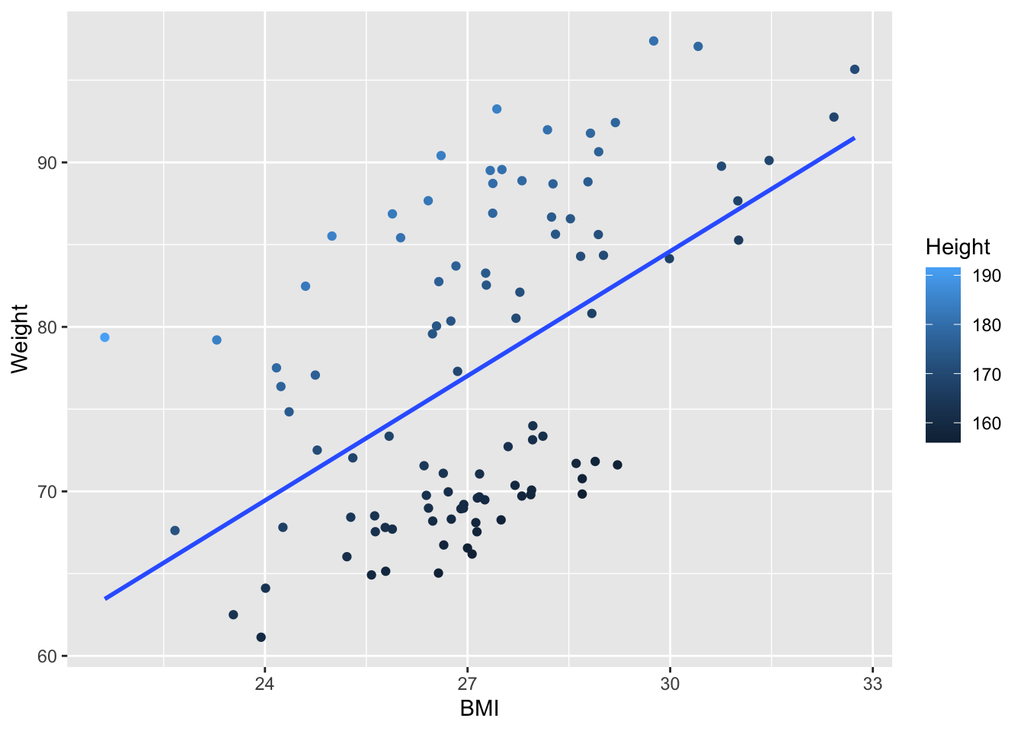

```r
plot <- ggplot(data=patients_clean,
               mapping=aes(x=BMI,y=Weight,colour=Height))+geom_point()+
  geom_smooth(method="lm",se=F)
plot
```

###Boxplots and Violin plots

7. Generate a boxplot of BMIs comparing smokers and non-smokers.

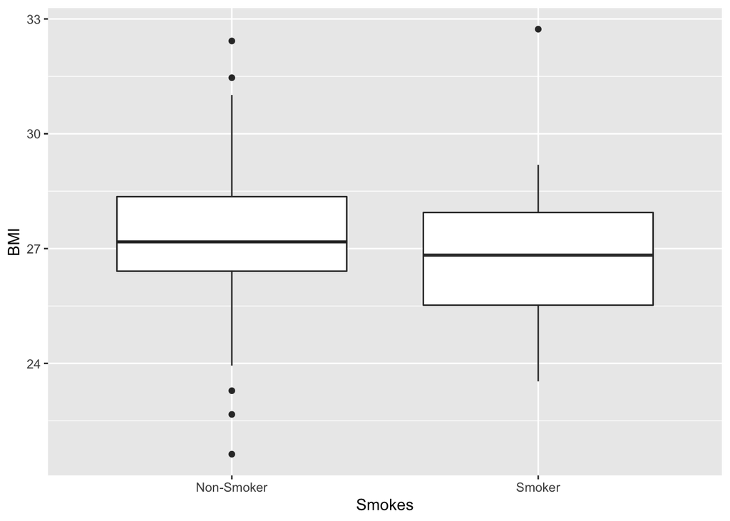

```r
plot <- ggplot(data=patients_clean,
               mapping=aes(x=Smokes,y=BMI))+geom_boxplot()
plot
```

8. Following from the boxplot comparing smokers and non-smokers in exercise 7, colour boxplot edges by Sex.

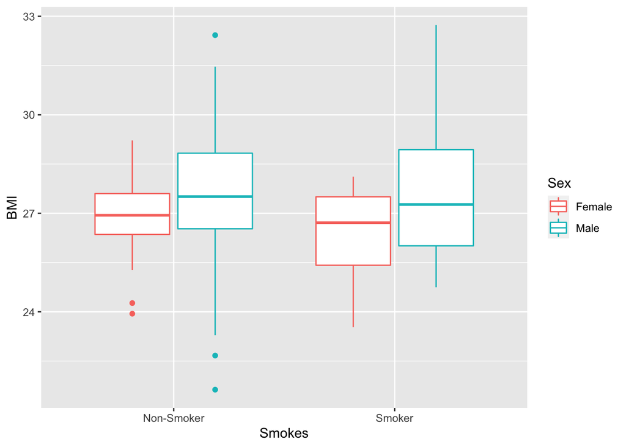

```r
plot <- ggplot(data=patients_clean,
               mapping=aes(x=Smokes,y=BMI,colour=Sex))+geom_boxplot()

plot
```

9. Now reproduce the boxplots in exercise 8 (grouped by smoker, coloured by sex) but now include a separate facet for people of different age (using Age column).

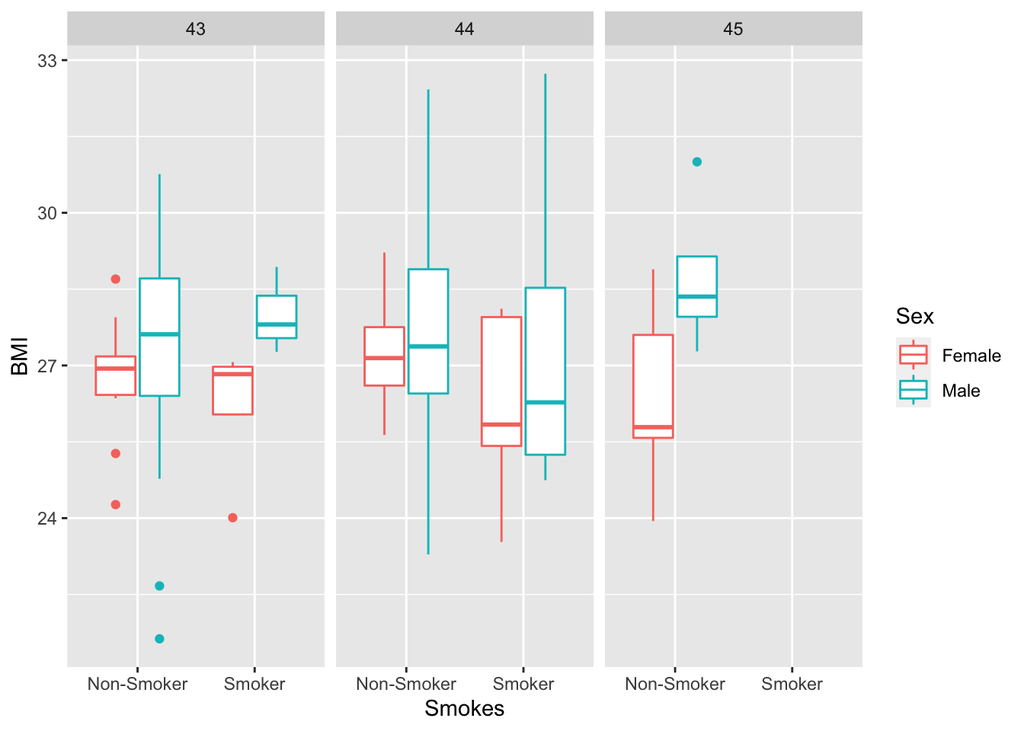

```r
plot <- ggplot(data=patients_clean,
               mapping=aes(x=Smokes,y=BMI,colour=Sex))+
  geom_boxplot()+
  facet_wrap(~Age)
plot
```

10. Produce a similar boxplot of BMIs but this time group data by Sex, colour by Age and facet by Smoking status.

HINT - Discrete values such as in factors are used for categorical data.

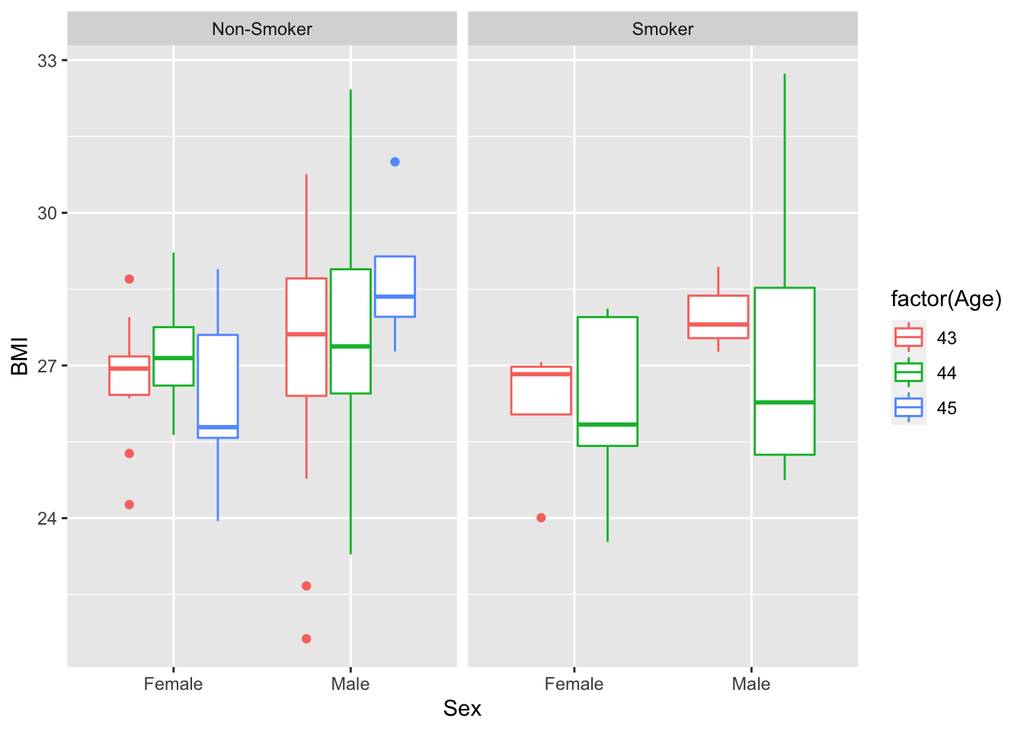

```r
plot <- ggplot(data=patients_clean,
               mapping=aes(x=Sex,y=BMI,colour=factor(Age)))+
  geom_boxplot()+
  facet_wrap(~Smokes)
plot
```

11. Regenerate the solution to exercise 10 but this time using a violin plot.

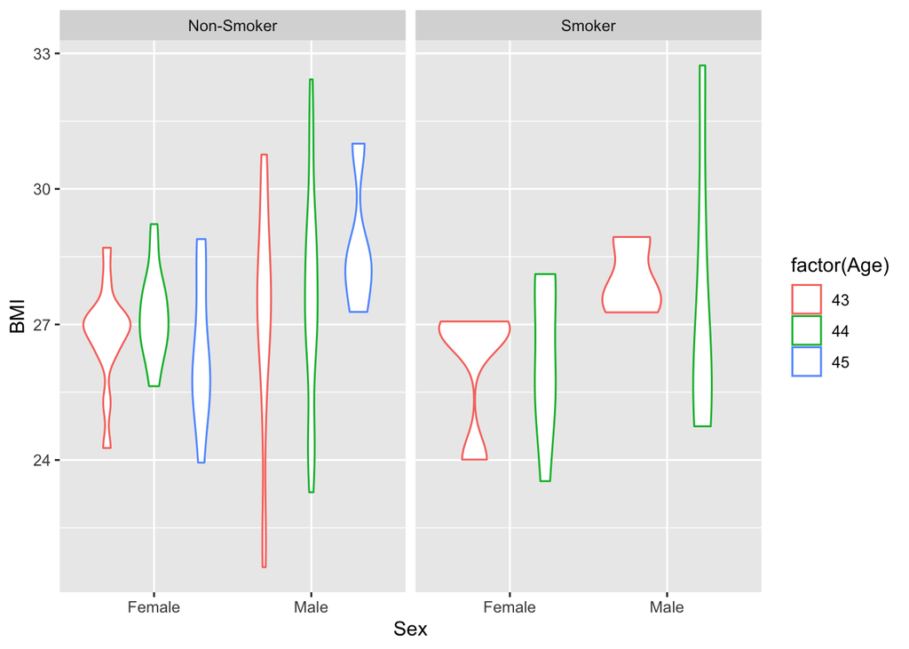

```r
plot <- ggplot(data=patients_clean,
               mapping=aes(x=Sex,y=BMI,colour=factor(Age)))+
  geom_violin()+
  facet_wrap(~Smokes)
plot
```

###Histogram and Density plots

12. Generate a histogram of BMIs with each bar coloured blue.

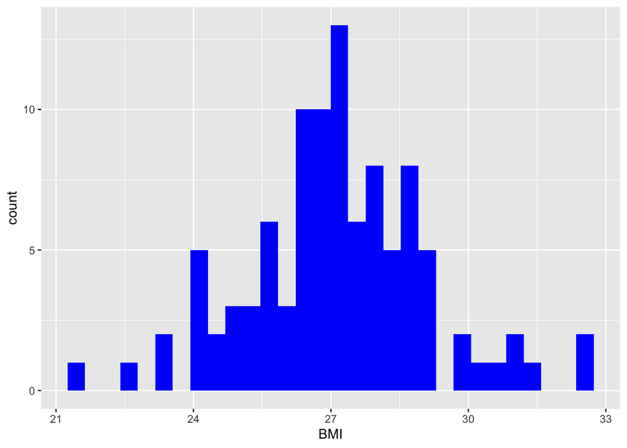

```r
plot <- ggplot(data=patients_clean,
               mapping=aes(BMI))+
  geom_histogram(fill="blue")
plot
```

13. Generate density plots of BMIs coloured by Sex.

HINT: alpha can be used to control transparancy.

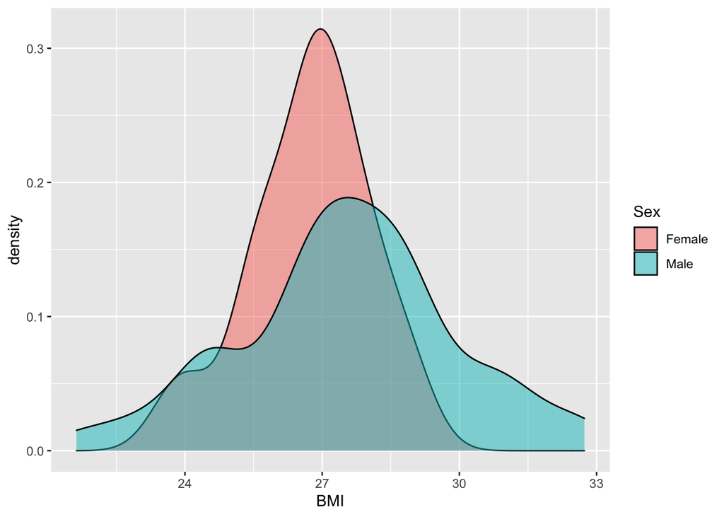

```r
plot <- ggplot(data=patients_clean,
               mapping=aes(BMI))+ geom_density(aes(fill=Sex),alpha=0.5)
plot
```

14. Generate a separate density plot of BMI coloured by sex for each Grade,

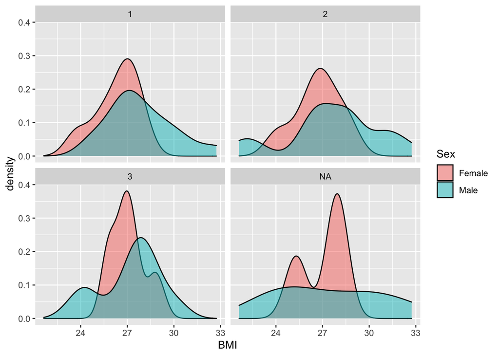

```r
plot <- ggplot(data=patients_clean,
               mapping=aes(BMI))+ geom_density(aes(fill=Sex),alpha=0.5)
plot+facet_wrap(~Grade)
```